Time Series Analysis in Python • Tutorial Series

# Part 2 — Statistical Properties & Decomposition

Stationarity, ACF/PACF, unit-root tests, and transformations

**Dataset:** Global monthly commodity prices, 1992–2021 (356 obs) **Stack:** statsmodels · scipy · arch · pandas **Level:** Intermediate

# Time Series Analysis in Python

## Part 2 — Statistical Properties & Decomposition

**Series:** *Time Series Analysis in Python — from Statistical Modeling to Machine Learning*

Part 1 taught us to *handle* time-indexed data and to *look* at it. Part 2 makes that looking **formal**. Before you can fit an ARIMA model (Part 4) or trust a forecast, you have to answer one question rigorously: **is this series stationary?** Almost every classical model assumes it, and the whole toolkit of this notebook exists to test for it and, when it fails, to *transform* the series until it holds.

### What you will learn

1. **Stationarity** — strict vs. weak, and precisely why it matters
2. **Autocorrelation (ACF)** and **partial autocorrelation (PACF)**, and how to read a correlogram
3. Formal tests — **ADF**, **KPSS**, and **Phillips–Perron** — and the trick of reading ADF and KPSS *together*
4. **Transformations to stationarity** — log, Box–Cox, first differencing, seasonal differencing
5. **Decomposition** revisited — classical additive vs. multiplicative, STL, and **MSTL** for multiple seasonalities
6. A repeatable **stationarity workflow** that turns any raw series into a model-ready one

### Recap of the dataset

We continue with `monthly_price.csv` — 356 months (Jan 1992–Aug 2021) of global commodity prices: fertilizers (`Urea_Price`, `MP_Price`, `TSP_Price`), crops (`Maize_Price`, `Rice_Price`, `Wheat_Price`), and market indices (`Food_Price_Index`, `Energy_Price_Index`, `VIX_Index`). In Part 1 the plots and an STL decomposition suggested these series are **trend/cycle-driven with light seasonality**. Now we prove it.

## 0. Setup and data

New libraries in this part: `statsmodels` for the tests and decompositions, `scipy` for Box–Cox, and `arch` for the Phillips–Perron test. We rebuild the `DatetimeIndex` exactly as in Part 1 — from the reliable `YEAR`/`MONTH` columns, with an explicit month-start frequency.

```python
import warnings
import numpy as np
import pandas as pd
import matplotlib.pyplot as plt
import matplotlib.dates as mdates

from statsmodels.tsa.stattools import adfuller, kpss, acf, pacf
from statsmodels.graphics.tsaplots import plot_acf, plot_pacf
from statsmodels.tsa.seasonal import seasonal_decompose, STL, MSTL
from scipy.stats import boxcox
from arch.unitroot import PhillipsPerron

plt.rcParams.update({
    "figure.figsize": (11, 4.2), "figure.dpi": 110,
    "axes.grid": True, "grid.alpha": 0.3,
    "axes.spines.top": False, "axes.spines.right": False,
    "axes.titlesize": 13, "axes.titleweight": "bold",
    "font.size": 11, "lines.linewidth": 1.6,
})
PALETTE = ["#2b6cb0", "#c05621", "#2f855a", "#6b46c1", "#b83280", "#718096"]

raw = pd.read_csv("monthly_price.csv")
dates = pd.to_datetime(raw["YEAR"].astype(str) + "-" + raw["MONTH"], format="%Y-%b")
df = raw.drop(columns=["ID", "YEAR", "MONTH", "TIME"]).copy()
df.index = dates; df.index.name = "date"
df = df.asfreq("MS")
print("shape:", df.shape, "| span:", df.index.min().date(), "->", df.index.max().date())
df.head(3)
```

```
shape: (356, 9) | span: 1992-01-01 -> 2021-08-01
```

| date | Urea_Price | MP_Price | TSP_Price | Maize_Price | Rice_Price | Wheat_Price | Food_Price_Index | Energy_Price_Index | VIX_Index |
| --- | --- | --- | --- | --- | --- | --- | --- | --- | --- |
| 1992-01-01 | 122.5 | 110.0 | 120.0 | 109.3 | 277.3 | 170.0 | 55.7 | 23.7 | 17.7 |
| 1992-02-01 | 120.6 | 110.0 | 120.0 | 113.6 | 278.3 | 177.1 | 55.5 | 23.8 | 17.5 |
| 1992-03-01 | 120.0 | 110.0 | 120.0 | 117.0 | 277.2 | 169.4 | 55.6 | 23.8 | 17.5 |

## 1. Stationarity — the central idea

A series is **stationary** when its statistical behaviour does not depend on *when* you look. Two definitions matter:

- **Strict stationarity** — the *entire* joint distribution of any set of observations is unchanged when shifted in time. This is a strong, mostly theoretical condition.
- **Weak (covariance) stationarity** — the practical one. It requires only three things:
  1. **constant mean** — no trend,
  2. **constant variance** — the spread doesn't grow or shrink over time,
  3. **autocovariance that depends only on the lag** — the relationship between $y_t$ and $y_{t-k}$ depends on the gap $k$, not on the position $t$.

**Why it matters.** Models like AR, MA, ARMA, and ARIMA are built on the assumption that the mechanism generating the data is stable. If the mean drifts or the variance explodes, estimated coefficients are unreliable and forecasts diverge. Making a series stationary is therefore not a formality — it is what licenses the models in Parts 3–4. Note the exception you already met: models like Holt–Winters and STL are *designed* to absorb trend and seasonality directly, so they don't require you to pre-stationarize.

Let's build the visual intuition first. A non-stationary series betrays itself: its **rolling mean drifts** and its **rolling variance changes**.

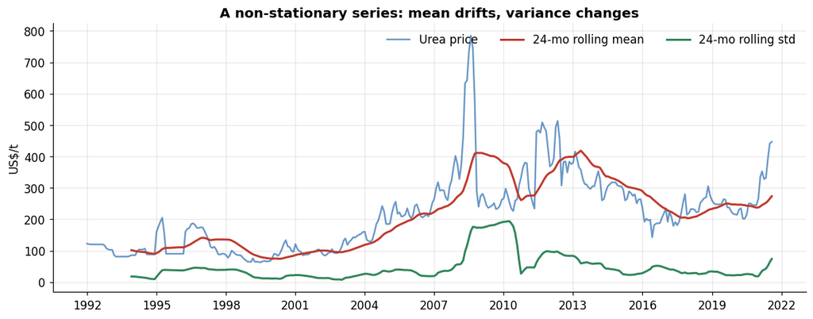

```python
s = df["Urea_Price"]
roll_mean = s.rolling(24).mean()
roll_std  = s.rolling(24).std()

fig, ax = plt.subplots(figsize=(11, 4.4))
ax.plot(s.index, s, color=PALETTE[0], alpha=0.7, label="Urea price")
ax.plot(roll_mean.index, roll_mean, color="#c0392b", lw=2, label="24-mo rolling mean")
ax.plot(roll_std.index, roll_std, color=PALETTE[2], lw=2, label="24-mo rolling std")
ax.set_title("A non-stationary series: mean drifts, variance changes")
ax.set_ylabel("US$/t"); ax.legend(frameon=False, ncol=3)
ax.xaxis.set_major_locator(mdates.YearLocator(3))
plt.tight_layout(); plt.show()
```

The rolling mean is clearly *not* flat — it climbs into 2008, collapses, and rises again — and the rolling standard deviation balloons around the 2008 spike. Both of the first two stationarity conditions fail. A blunt way to see the same thing: split the series in half and compare the two halves' statistics.

```python
half = len(s) // 2
first, second = s.iloc[:half], s.iloc[half:]
summary = pd.DataFrame({
    "segment": ["1992–2006 (1st half)", "2007–2021 (2nd half)"],
    "mean":    [first.mean(),  second.mean()],
    "std":     [first.std(),   second.std()],
    "variance":[first.var(),   second.var()],
}).round(1)
summary
```

|  | segment | mean | std | variance |
| --- | --- | --- | --- | --- |
| 0 | 1992–2006 (1st half) | 124.6 | 49.8 | 2481.7 |
| 1 | 2007–2021 (2nd half) | 303.3 | 104.7 | 10958.6 |

The mean and the variance are dramatically different between the two halves — the numerical fingerprint of non-stationarity. We'll return to this exact series after transforming it and watch these numbers converge.

## 2. Autocorrelation (ACF) and partial autocorrelation (PACF)

**Autocorrelation** measures how correlated a series is with a lagged copy of itself. The **ACF** at lag $k$ is the correlation between $y_t$ and $y_{t-k}$. Plotted across many lags, it becomes a **correlogram** — the single most useful diagnostic in classical time-series analysis.

- **Slow, near-linear decay** in the ACF is the signature of a **trend / non-stationary** series (each value is close to the last, so correlation dies off only gradually).
- **Spikes at seasonal lags** (12, 24, … for monthly data) reveal **seasonality**.
- **Fast decay to zero** indicates a **stationary**, short-memory series.

The **PACF** (partial autocorrelation) at lag $k$ is the correlation between $y_t$ and $y_{t-k}$ *after removing* the influence of all the intermediate lags $1 \dots k-1$. Where the ACF shows total association, the PACF isolates the **direct** effect at each lag. The two together are what let you read off the order of an ARIMA model in Part 4.

The shaded band in each plot is the ~95% confidence interval; bars inside it are statistically indistinguishable from zero.

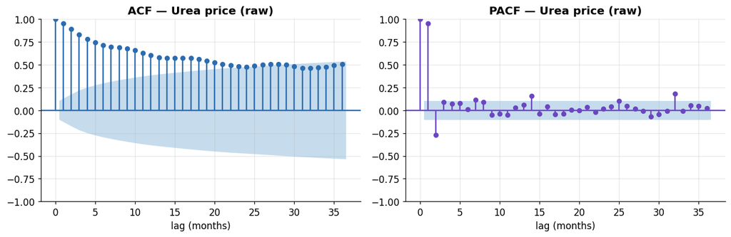

```python
fig, axes = plt.subplots(1, 2, figsize=(12, 4))
plot_acf(s, lags=36, ax=axes[0], color=PALETTE[0], vlines_kwargs={"colors": PALETTE[0]})
plot_pacf(s, lags=36, ax=axes[1], method="ywm", color=PALETTE[3],
          vlines_kwargs={"colors": PALETTE[3]})
axes[0].set_title("ACF — Urea price (raw)")
axes[1].set_title("PACF — Urea price (raw)")
for a in axes: a.set_xlabel("lag (months)")
plt.tight_layout(); plt.show()
```

For contrast, here is the ACF/PACF of the *first-differenced* series — jumping ahead slightly to show what "stationary" looks like.

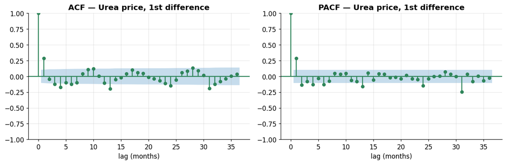

```python
d1 = s.diff().dropna()
fig, axes = plt.subplots(1, 2, figsize=(12, 4))
plot_acf(d1, lags=36, ax=axes[0], color=PALETTE[2], vlines_kwargs={"colors": PALETTE[2]})
plot_pacf(d1, lags=36, ax=axes[1], method="ywm", color=PALETTE[2],
          vlines_kwargs={"colors": PALETTE[2]})
axes[0].set_title("ACF — Urea price, 1st difference")
axes[1].set_title("PACF — Urea price, 1st difference")
for a in axes: a.set_xlabel("lag (months)")
plt.tight_layout(); plt.show()
```

After one difference the ACF **collapses to near zero after a couple of lags** — the slow decay is gone. The trend has been removed and the series now looks short-memory and stationary. We'll confirm that with formal tests rather than eyeballing.

> **How ACF/PACF map to model orders (a preview of Part 4).** For a stationary series: an **AR(p)** process shows a PACF that *cuts off* after lag $p$ and an ACF that *tails off*; an **MA(q)** process shows the mirror image — ACF cuts off after lag $q$, PACF tails off. Keep this rule in your pocket; it is how we pick ARIMA orders later.

## 3. Formal tests for stationarity

Eyeballing rolling statistics and correlograms is necessary but not sufficient. Three hypothesis tests put a number on it. The crucial subtlety is that **they do not all share the same null hypothesis** — so you must read them carefully, and ideally in combination.

### 3.1 Augmented Dickey–Fuller (ADF)

The ADF test checks for a **unit root** (the mathematical source of a stochastic trend).

- **H₀:** the series *has a unit root* → **non-stationary**
- **H₁:** no unit root → **stationary**
- **Decision:** if *p* < 0.05, **reject H₀** ⇒ conclude **stationary**.

```python
def adf_test(series):
    series = series.dropna()
    stat, p, lags, nobs, crit, _ = adfuller(series, autolag="AIC", result_object=False)
    return {"test": "ADF", "statistic": round(stat, 3), "p_value": round(p, 4),
            "used_lags": lags, "conclusion": "stationary" if p < 0.05 else "non-stationary"}

pd.DataFrame([adf_test(s)])
```

|  | test | statistic | p_value | used_lags | conclusion |
| --- | --- | --- | --- | --- | --- |
| 0 | ADF | -1.583 | 0.4921 | 13 | non-stationary |

ADF cannot reject the unit root for raw Urea price (*p* ≈ 0.49) — it reads as **non-stationary**, matching the correlogram.

### 3.2 Kwiatkowski–Phillips–Schmidt–Shin (KPSS)

KPSS flips the logic — its null is the *opposite* of ADF's.

- **H₀:** the series *is* (trend- or level-) **stationary**
- **H₁:** non-stationary
- **Decision:** if *p* < 0.05, **reject H₀** ⇒ conclude **non-stationary**.

```python
def kpss_test(series, regression="c"):
    series = series.dropna()
    with warnings.catch_warnings():
        warnings.simplefilter("ignore")
        stat, p, lags, crit = kpss(series, regression=regression, nlags="auto")
    note = " (p capped at table bound)" if p in (0.01, 0.10) else ""
    return {"test": "KPSS", "statistic": round(stat, 3), "p_value": round(p, 4),
            "used_lags": lags,
            "conclusion": ("non-stationary" if p < 0.05 else "stationary") }

pd.DataFrame([kpss_test(s)])
```

|  | test | statistic | p_value | used_lags | conclusion |
| --- | --- | --- | --- | --- | --- |
| 0 | KPSS | 1.664 | 0.01 | 11 | non-stationary |

### 3.3 Phillips–Perron (PP)

Phillips–Perron tests the same unit-root null as ADF but corrects for autocorrelation and heteroscedasticity **non-parametrically** rather than by adding lagged terms. It is a useful robustness check alongside ADF, and lives in the `arch` package.

- **H₀:** unit root → **non-stationary**; reject (*p* < 0.05) ⇒ **stationary**.

```python
def pp_test(series):
    series = series.dropna()
    pp = PhillipsPerron(series)
    return {"test": "Phillips–Perron", "statistic": round(pp.stat, 3),
            "p_value": round(pp.pvalue, 4),
            "conclusion": "stationary" if pp.pvalue < 0.05 else "non-stationary"}

pd.DataFrame([pp_test(s)])
```

|  | test | statistic | p_value | conclusion |
| --- | --- | --- | --- | --- |
| 0 | Phillips–Perron | -2.139 | 0.2293 | non-stationary |

### 3.4 Reading ADF and KPSS *together*

Because ADF and KPSS have opposite nulls, their four possible combinations map to four distinct situations — this 2×2 is one of the most practically useful tables in the whole subject:

| ADF result | KPSS result | Interpretation | Action |
| --- | --- | --- | --- |
| Stationary | Stationary | **Stationary** | Model as-is |
| Non-stationary | Non-stationary | **Non-stationary** | Difference the series |
| Stationary | Non-stationary | **Difference-stationary** | Difference the series |
| Non-stationary | Stationary | **Trend-stationary** | Remove a deterministic trend (detrend) |

Let's wrap all three tests into one report we can reuse on any series.

```python
def stationarity_report(series, name="series"):
    adf, kp, pp = adf_test(series), kpss_test(series), pp_test(series)
    combo = {("stationary","stationary"): "stationary",
             ("non-stationary","non-stationary"): "non-stationary (difference)",
             ("stationary","non-stationary"): "difference-stationary (difference)",
             ("non-stationary","stationary"): "trend-stationary (detrend)"}
    verdict = combo[(adf["conclusion"], kp["conclusion"])]
    return pd.DataFrame([adf, kp, pp]).assign(series=name), verdict

report, verdict = stationarity_report(s, "Urea_Price (raw)")
print("Combined ADF+KPSS verdict:", verdict, "\n")
report
```

```
Combined ADF+KPSS verdict: non-stationary (difference)
```

|  | test | statistic | p_value | used_lags | conclusion | series |
| --- | --- | --- | --- | --- | --- | --- |
| 0 | ADF | -1.583 | 0.4921 | 13.0 | non-stationary | Urea_Price (raw) |
| 1 | KPSS | 1.664 | 0.0100 | 11.0 | non-stationary | Urea_Price (raw) |
| 2 | Phillips–Perron | -2.139 | 0.2293 | NaN | non-stationary | Urea_Price (raw) |

```python
rows = []
for col in df.columns:
    rep, verdict = stationarity_report(df[col], col)
    adf_p = rep.loc[rep.test == "ADF", "p_value"].iloc[0]
    kpss_p = rep.loc[rep.test == "KPSS", "p_value"].iloc[0]
    rows.append({"series": col, "ADF_p": adf_p, "KPSS_p": kpss_p, "verdict": verdict})
pd.DataFrame(rows)
```

|  | series | ADF_p | KPSS_p | verdict |
| --- | --- | --- | --- | --- |
| 0 | Urea_Price | 0.4921 | 0.01 | non-stationary (difference) |
| 1 | MP_Price | 0.4961 | 0.01 | non-stationary (difference) |
| 2 | TSP_Price | 0.2547 | 0.01 | non-stationary (difference) |
| 3 | Maize_Price | 0.3385 | 0.01 | non-stationary (difference) |
| 4 | Rice_Price | 0.4441 | 0.01 | non-stationary (difference) |
| 5 | Wheat_Price | 0.1205 | 0.01 | non-stationary (difference) |
| 6 | Food_Price_Index | 0.6090 | 0.01 | non-stationary (difference) |
| 7 | Energy_Price_Index | 0.2004 | 0.01 | non-stationary (difference) |
| 8 | VIX_Index | 0.0001 | 0.10 | stationary |

## 4. Transformations to stationarity

When a series fails the tests, we transform it. There are two distinct problems to fix, and they call for different tools:

1. **Non-constant variance** (spread grows with level) → **variance-stabilizing** transforms: **log** or **Box–Cox**.
2. **Non-constant mean** (trend, seasonality) → **differencing**: first difference for trend, seasonal difference for seasonality.

Do variance stabilization *first*, then differencing.

### 4.1 Log and Box–Cox — stabilizing the variance

A **log** transform compresses large values more than small ones, taming a variance that grows with the level. **Box–Cox** generalizes this with a parameter λ that the data chooses: λ = 0 is exactly the log, λ = 1 is (essentially) no transform. Box–Cox requires strictly positive data, which all our prices satisfy.

```
Box–Cox chose lambda = 0.058  (0 = log, 1 = no transform)
```

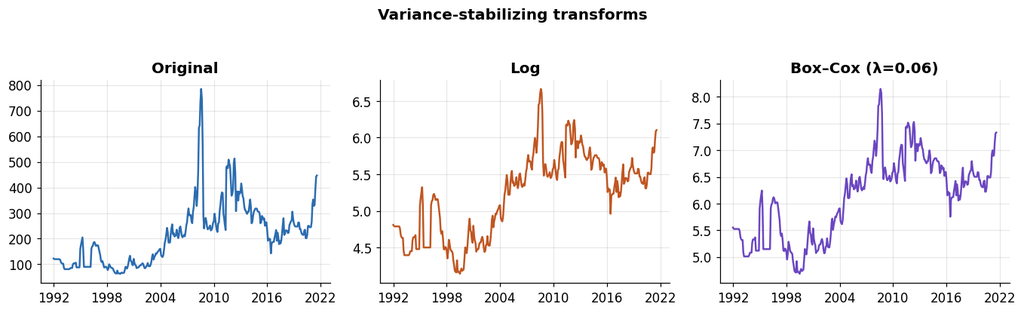

```python
s_pos = s.dropna()
s_log = np.log(s_pos)
bc_values, lam = boxcox(s_pos)
s_bc = pd.Series(bc_values, index=s_pos.index)
print(f"Box–Cox chose lambda = {lam:.3f}  (0 = log, 1 = no transform)")

fig, axes = plt.subplots(1, 3, figsize=(12.5, 3.6))
for ax, (data, title, c) in zip(axes, [
        (s_pos, "Original", PALETTE[0]),
        (s_log, "Log", PALETTE[1]),
        (s_bc,  f"Box–Cox (λ={lam:.2f})", PALETTE[3])]):
    ax.plot(data.index, data, color=c); ax.set_title(title)
    ax.xaxis.set_major_locator(mdates.YearLocator(6))
plt.suptitle("Variance-stabilizing transforms", fontweight="bold", y=1.04)
plt.tight_layout(); plt.show()
```

λ ≈ 0.06 is very close to zero, so Box–Cox is telling us a **log transform is about right** for this series — unsurprising for prices, whose fluctuations tend to scale with their level. Notice the 2008 spike is much less violent on the log and Box–Cox scales: the variance is more even across time. But the **trend remains** — variance stabilization alone does not create stationarity.

### 4.2 Differencing — removing the trend

The **first difference** $\nabla y_t = y_t - y_{t-1}$ removes a linear trend and usually delivers stationarity in one step. If one difference isn't enough you can difference again (second-order), but rarely need more than two — over-differencing introduces artificial negative autocorrelation, so stop as soon as the tests pass.

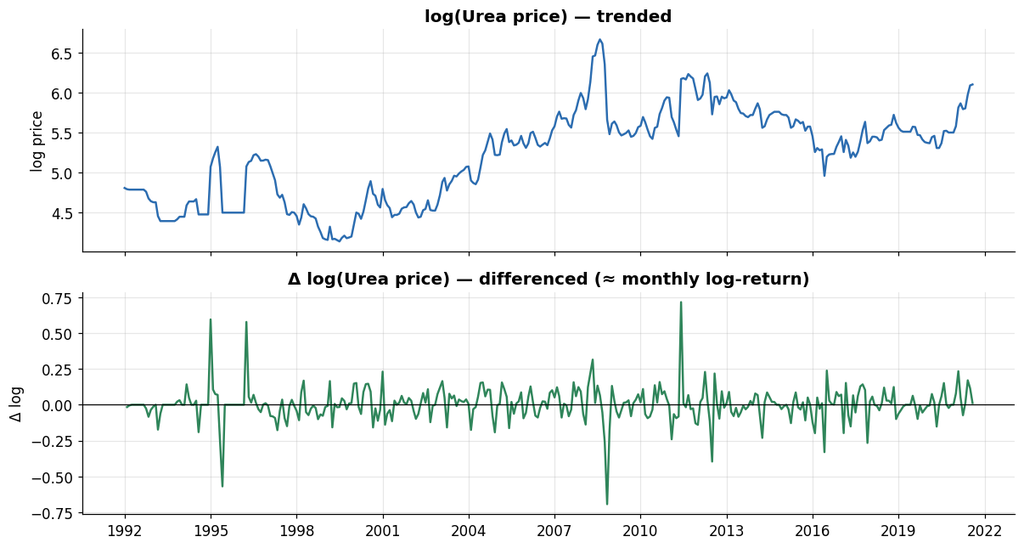

```
Verdict after log + 1st difference: stationary
```

|  | test | statistic | p_value | used_lags | conclusion | series |
| --- | --- | --- | --- | --- | --- | --- |
| 0 | ADF | -9.985 | 0.0 | 4.0 | stationary | Δlog Urea |
| 1 | KPSS | 0.040 | 0.1 | 4.0 | stationary | Δlog Urea |
| 2 | Phillips–Perron | -15.699 | 0.0 | NaN | stationary | Δlog Urea |

```python
s_log_d1 = s_log.diff().dropna()   # log first, then difference (stabilize + detrend)

fig, axes = plt.subplots(2, 1, figsize=(11, 6), sharex=True)
axes[0].plot(s_log.index, s_log, color=PALETTE[0]); axes[0].set_title("log(Urea price) — trended")
axes[0].set_ylabel("log price")
axes[1].plot(s_log_d1.index, s_log_d1, color=PALETTE[2]); axes[1].axhline(0, color="k", lw=0.8)
axes[1].set_title("Δ log(Urea price) — differenced (≈ monthly log-return)")
axes[1].set_ylabel("Δ log"); axes[1].xaxis.set_major_locator(mdates.YearLocator(3))
plt.tight_layout(); plt.show()

report_d, verdict_d = stationarity_report(s_log_d1, "Δlog Urea")
print("Verdict after log + 1st difference:", verdict_d, "\n")
report_d
```

After a log-and-difference the series oscillates around a **constant zero mean** with roughly stable variance, and all three tests now agree it is **stationary**. Return to the split-half check from Section 1 to see the numbers converge.

```python
h = len(s_log_d1) // 2
comp = pd.DataFrame({
    "segment": ["1st half", "2nd half"],
    "mean": [s_log_d1.iloc[:h].mean(), s_log_d1.iloc[h:].mean()],
    "std":  [s_log_d1.iloc[:h].std(),  s_log_d1.iloc[h:].std()],
}).round(4)
comp
```

|  | segment | mean | std |
| --- | --- | --- | --- |
| 0 | 1st half | 0.0030 | 0.1092 |
| 1 | 2nd half | 0.0043 | 0.1260 |

The two halves' means are both essentially zero and their standard deviations are close — exactly what Section 1's non-stationary version failed to show. The series is now **model-ready**.

### 4.3 Seasonal differencing

When a series has a seasonal cycle, a **seasonal difference** $y_t - y_{t-m}$ (with $m=12$ for monthly data) removes it. Our commodities are only lightly seasonal, so we demonstrate the mechanics and confirm — via ACF — that no strong seasonal spikes remain to justify it here.

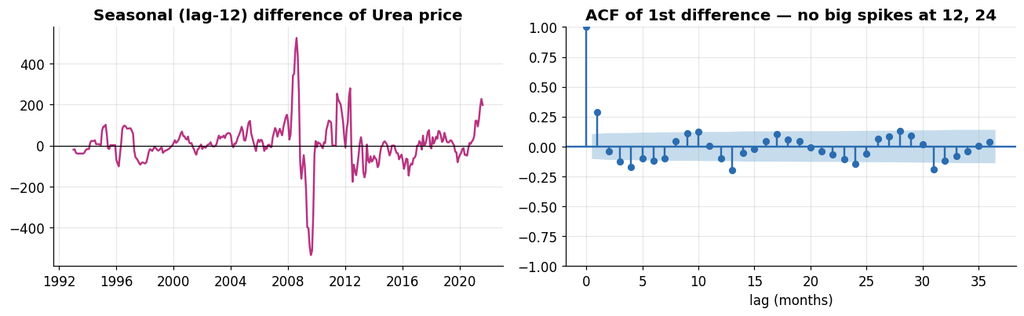

```python
s_seasonal_d = s.diff(12).dropna()   # year-over-year difference

fig, axes = plt.subplots(1, 2, figsize=(12, 3.8))
axes[0].plot(s_seasonal_d.index, s_seasonal_d, color=PALETTE[4])
axes[0].axhline(0, color="k", lw=0.8)
axes[0].set_title("Seasonal (lag-12) difference of Urea price")
axes[0].xaxis.set_major_locator(mdates.YearLocator(4))
plot_acf(s.diff().dropna(), lags=36, ax=axes[1], color=PALETTE[0],
         vlines_kwargs={"colors": PALETTE[0]})
axes[1].set_title("ACF of 1st difference — no big spikes at 12, 24")
axes[1].set_xlabel("lag (months)")
plt.tight_layout(); plt.show()
```

In the ACF of the first difference there is **no dominant spike at lags 12 or 24**, confirming Part 1's finding that seasonality is weak here — so a plain first difference suffices and we don't *need* the seasonal one. For a strongly seasonal series (retail sales, electricity demand) you would often apply *both* a seasonal and a first difference.

## 5. Decomposition — separating the components

Differencing *removes* structure to reach stationarity. **Decomposition** instead *exposes* the structure, splitting a series into trend, seasonal, and residual parts you can inspect. Part 1 introduced STL; here we treat the family properly.

### 5.1 Classical decomposition: additive vs. multiplicative

Classical `seasonal_decompose` estimates the trend with a moving average, then the seasonal component as the average detrended value per month. The modelling choice is **additive** vs. **multiplicative**:

- **Additive** $y_t = T_t + S_t + R_t$ — use when the seasonal swing is roughly **constant** in absolute size regardless of level.
- **Multiplicative** $y_t = T_t \times S_t \times R_t$ — use when the swing **grows with the level** (common for prices; equivalently, additive on the log).

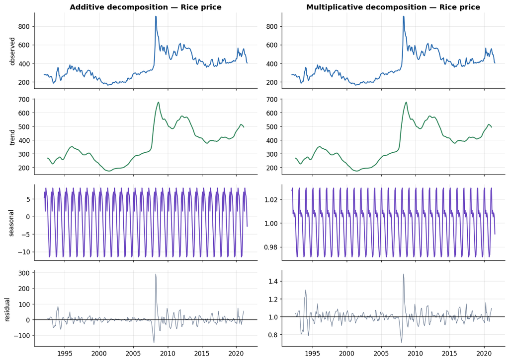

```python
series = df["Rice_Price"]
add = seasonal_decompose(series, model="additive", period=12)
mul = seasonal_decompose(series, model="multiplicative", period=12)

fig, axes = plt.subplots(4, 2, figsize=(12.5, 9), sharex=True)
for j, (dec, title) in enumerate([(add, "Additive"), (mul, "Multiplicative")]):
    axes[0, j].plot(series.index, dec.observed, color=PALETTE[0])
    axes[0, j].set_title(f"{title} decomposition — Rice price")
    axes[1, j].plot(series.index, dec.trend, color=PALETTE[2])
    axes[2, j].plot(series.index, dec.seasonal, color=PALETTE[3])
    axes[3, j].plot(series.index, dec.resid, color=PALETTE[5], lw=0.9)
    axes[3, j].axhline(1 if title == "Multiplicative" else 0, color="k", lw=0.8)
    axes[3, j].xaxis.set_major_locator(mdates.YearLocator(5))
for i, lab in enumerate(["observed", "trend", "seasonal", "residual"]):
    axes[i, 0].set_ylabel(lab)
plt.tight_layout(); plt.show()
```

How do we choose objectively? The better model leaves a residual with **no remaining structure** — its residual should look most like flat noise. A simple proxy is the residual's coefficient of variation, or the correlation of the residual with the level (a good decomposition leaves them uncorrelated).

```python
def residual_quality(dec, multiplicative=False):
    resid = dec.resid.dropna()
    center = 1.0 if multiplicative else 0.0
    # correlation between |residual| and the trend level: near 0 is better
    trend = dec.trend.reindex(resid.index)
    corr = np.corrcoef((resid - center).abs(), trend)[0, 1]
    return {"resid_std": round(resid.std(), 4),
            "abs_resid ~ level corr": round(corr, 3)}

pd.DataFrame({
    "additive":       residual_quality(add, multiplicative=False),
    "multiplicative": residual_quality(mul, multiplicative=True),
}).T
```

|  | resid_std | abs_resid ~ level corr |
| --- | --- | --- |
| additive | 33.9888 | 0.377 |
| multiplicative | 0.0744 | 0.181 |

The multiplicative residual is far less correlated with the level, i.e. its errors no longer grow with price — the expected result for commodity prices and a concrete reason to prefer the multiplicative view (or, equivalently, to work on the log scale as we did in Section 4).

### 5.2 STL — a robust, flexible decomposition

**STL** (Seasonal-Trend using Loess) is more flexible than classical decomposition: it lets the seasonal shape evolve slowly over time, handles outliers when `robust=True`, and doesn't discard endpoints the way a centered moving average does. We met it in Part 1; here we use it to **deseasonalize** — subtract the seasonal component to isolate trend-plus-noise, a common preprocessing step.

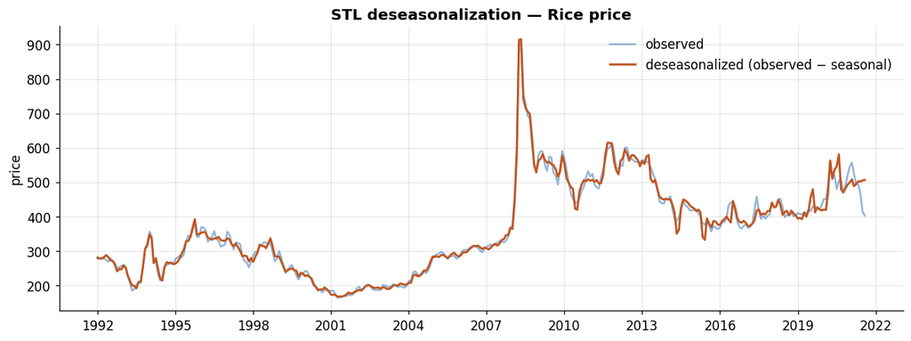

```python
stl = STL(series, period=12, robust=True).fit()
deseasonalized = series - stl.seasonal

fig, ax = plt.subplots(figsize=(11, 4.2))
ax.plot(series.index, series, color=PALETTE[0], alpha=0.5, label="observed")
ax.plot(deseasonalized.index, deseasonalized, color=PALETTE[1], lw=1.8,
        label="deseasonalized (observed − seasonal)")
ax.set_title("STL deseasonalization — Rice price")
ax.set_ylabel("price"); ax.legend(frameon=False)
ax.xaxis.set_major_locator(mdates.YearLocator(3))
plt.tight_layout(); plt.show()
```

### 5.3 MSTL — multiple seasonalities

Classical and STL decomposition assume **one** seasonal period. Many real series have **several** at once — hourly electricity demand has a *daily* cycle **and** a *weekly* cycle; retail data can carry weekly and yearly patterns. **MSTL** (Multiple STL) peels off each seasonal period in turn.

Our monthly commodity data has only one natural cycle (annual, period 12), so to show MSTL doing its distinctive job we build a small **synthetic** daily series with a 7-day *and* a 30-day cycle, then let MSTL separate them.

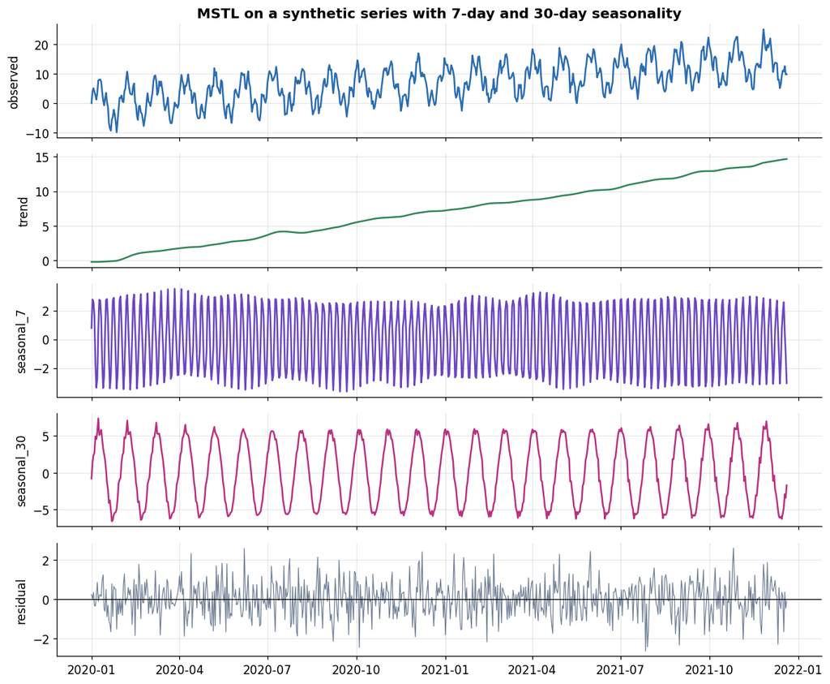

```python
rng = np.random.default_rng(7)
n = 24 * 30                              # ~2 years of daily data
t = np.arange(n)
weekly  = 3.0 * np.sin(2 * np.pi * t / 7)      # 7-day cycle
monthly = 6.0 * np.sin(2 * np.pi * t / 30)     # 30-day cycle
trend   = 0.02 * t
synthetic = pd.Series(trend + weekly + monthly + rng.normal(0, 1.2, n),
                      index=pd.date_range("2020-01-01", periods=n, freq="D"),
                      name="synthetic")

mstl = MSTL(synthetic, periods=(7, 30)).fit()
fig, axes = plt.subplots(5, 1, figsize=(11, 9), sharex=True)
axes[0].plot(synthetic.index, synthetic, color=PALETTE[0]); axes[0].set_ylabel("observed")
axes[0].set_title("MSTL on a synthetic series with 7-day and 30-day seasonality")
axes[1].plot(mstl.trend.index, mstl.trend, color=PALETTE[2]); axes[1].set_ylabel("trend")
seas = mstl.seasonal
axes[2].plot(seas.index, seas["seasonal_7"],  color=PALETTE[3]); axes[2].set_ylabel("seasonal_7")
axes[3].plot(seas.index, seas["seasonal_30"], color=PALETTE[4]); axes[3].set_ylabel("seasonal_30")
axes[4].plot(mstl.resid.index, mstl.resid, color=PALETTE[5], lw=0.8); axes[4].set_ylabel("residual")
axes[4].axhline(0, color="k", lw=0.8)
plt.tight_layout(); plt.show()
```

MSTL cleanly recovers **both** injected cycles into separate `seasonal_7` and `seasonal_30` panels, plus the underlying trend — something single-period decomposition cannot do. When you meet high-frequency data in later parts, this is the tool that untangles its overlapping rhythms.

## 6. The stationarity workflow, end-to-end

Putting the pieces together, here is the repeatable procedure to take *any* raw series to a model-ready stationary one:

1. **Plot** the series and its rolling mean/std — form a hypothesis.
2. **Test** with ADF + KPSS (add PP for robustness); read them *together*.
3. If variance grows with level → **log / Box–Cox**.
4. If a trend remains → **first difference**; if seasonality remains → **seasonal difference**.
5. **Re-test** after each transform; stop as soon as the series is stationary (don't over-difference).

Let's run it as a single function on a fresh series — `Energy_Price_Index` — and report the transform that gets us there.

```
Transforms applied: log -> diff #1
Final verdict      : stationary
```

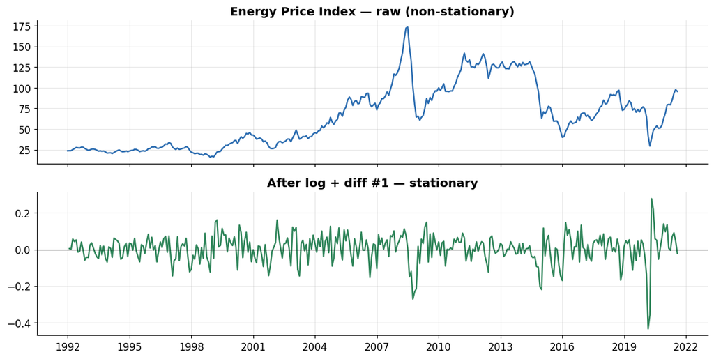

```python
def make_stationary(series, name="series", max_d=2):
    log = np.log(series.dropna())
    _, verdict = stationarity_report(log, name)
    steps = ["log"]
    work = log
    d = 0
    while "stationary" != verdict.split()[0] and d < max_d:
        work = work.diff().dropna(); d += 1
        _, verdict = stationarity_report(work, name)
        steps.append(f"diff #{d}")
    return work, steps, verdict

energy = df["Energy_Price_Index"]
stat_series, steps, final_verdict = make_stationary(energy, "Energy_Price_Index")
print("Transforms applied:", " -> ".join(steps))
print("Final verdict      :", final_verdict)

fig, axes = plt.subplots(2, 1, figsize=(11, 5.6), sharex=True)
axes[0].plot(energy.index, energy, color=PALETTE[0]); axes[0].set_title("Energy Price Index — raw (non-stationary)")
axes[1].plot(stat_series.index, stat_series, color=PALETTE[2]); axes[1].axhline(0, color="k", lw=0.8)
axes[1].set_title(f"After {' + '.join(steps)} — stationary")
axes[1].xaxis.set_major_locator(mdates.YearLocator(3))
plt.tight_layout(); plt.show()
```

## 7. Exercises

Work these against the same `df`; a solution to the first is provided.

1. **Full report.** Run `stationarity_report` on `Wheat_Price` raw, then on its log-first-difference. Confirm the transform achieves stationarity.
2. **Correlograms.** Plot ACF and PACF (36 lags) for `MP_Price` raw and differenced. Describe how the slow decay disappears.
3. **Box–Cox by series.** Compute the Box–Cox λ for each of the three fertilizer prices. Which is closest to a pure log (λ ≈ 0)?
4. **Additive vs multiplicative.** Decompose `Maize_Price` both ways and use the `residual_quality` helper to argue which model fits better.
5. **Seasonal strength.** Using STL on `Rice_Price`, compute the seasonal strength $\max(0,\,1 - \mathrm{Var}(R)/\mathrm{Var}(S+R))$ and compare it to the trend strength. Does the number match the "light seasonality" story?

```python
# --- Solution to Exercise 1 ---
wheat = df["Wheat_Price"]
rep_raw,  v_raw  = stationarity_report(wheat, "Wheat raw")
wheat_t = np.log(wheat).diff().dropna()
rep_tr,   v_tr   = stationarity_report(wheat_t, "Wheat Δlog")
print("Wheat raw   verdict:", v_raw)
print("Wheat Δlog  verdict:", v_tr)
pd.concat([rep_raw.assign(version="raw"),
           rep_tr.assign(version="Δlog")], ignore_index=True)
```

```
Wheat raw   verdict: non-stationary (difference)
Wheat Δlog  verdict: stationary
```

|  | test | statistic | p_value | used_lags | conclusion | series | version |
| --- | --- | --- | --- | --- | --- | --- | --- |
| 0 | ADF | -2.480 | 0.1205 | 7.0 | non-stationary | Wheat raw | raw |
| 1 | KPSS | 0.902 | 0.0100 | 11.0 | non-stationary | Wheat raw | raw |
| 2 | Phillips–Perron | -2.249 | 0.1891 | NaN | non-stationary | Wheat raw | raw |
| 3 | ADF | -15.268 | 0.0000 | 0.0 | stationary | Wheat Δlog | Δlog |
| 4 | KPSS | 0.074 | 0.1000 | 2.0 | stationary | Wheat Δlog | Δlog |
| 5 | Phillips–Perron | -15.023 | 0.0000 | NaN | stationary | Wheat Δlog | Δlog |

## 8. Key takeaways

- **Stationarity** — constant mean, constant variance, lag-only autocovariance — is the assumption classical models rest on. Test for it before modelling.
- The **ACF/PACF correlogram** is your fastest diagnostic: slow ACF decay ⇒ trend/non-stationary; spikes at 12, 24 ⇒ seasonality; fast decay ⇒ stationary. The AR/MA cut-off rules preview ARIMA order selection in Part 4.
- **ADF** and **KPSS** have *opposite* nulls; read them **together** via the 2×2 table to distinguish difference-stationary from trend-stationary. **Phillips– Perron** is a robustness check on ADF.
- Fix **variance** with log/Box–Cox *first*, then fix the **mean** with differencing. Stop as soon as the tests pass — over-differencing does harm.
- **Decomposition** exposes structure: choose **additive vs. multiplicative** by which leaves a structureless residual (multiplicative ≈ log-additive, and fits our prices better); **STL** is the robust workhorse; **MSTL** handles multiple seasonalities.

### What's next — Part 3: Smoothing & Exponential Methods

With stationarity understood, Part 3 turns to our **first forecasting models**: moving averages, simple exponential smoothing, Holt's linear trend, and Holt–Winters seasonal smoothing — models that, unlike ARIMA, absorb trend and seasonality directly and give us honest baselines to beat.